# Random Data

Monika Peteva Petkova

mpetevap@uni-sofia.bg

2018

# Discrete Distriution

- Probability mass function (pmf)
- Cumulative distribution function (cmf)
- Moments
- - First moment - Mean - EX
- - Second moment - Variance - VarX
- - Third moment - Skewness
- - Fourth moment - Kurtosis

## [Uniform discrete distribution (Дискретно равномерно разпределение)](https://en.wikipedia.org/wiki/Discrete_uniform_distribution)

A known, finite number of outcomes equally likely to happen. **X ~ U(min, max)** **X ~ Unif(min, max)**

Probability mass function (pmf) of the Uniform distribution

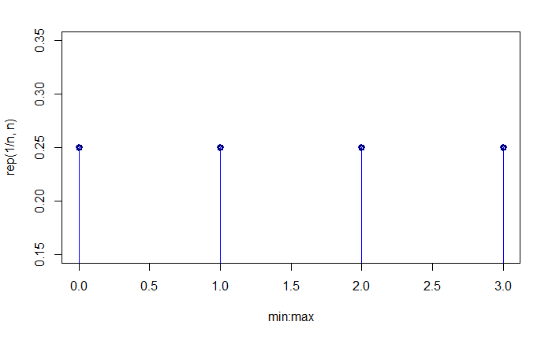

```r
min = 0
max = 3
n = max - min + 1
plot(min:max, rep(1/n, n), type = "h", col = "blue")
points(min:max, rep(1 / n, n), type = "p", lwd = 3, col = "darkblue")
```

**sample**(x, size, replace = FALSE)

### Example 1:

Row a dice 10 times.

```r
sample(1:6, size = 10, replace = TRUE)
```

```
 [1] 1 2 2 4 6 5 3 3 5 4
```

Probability mass function (pmf)

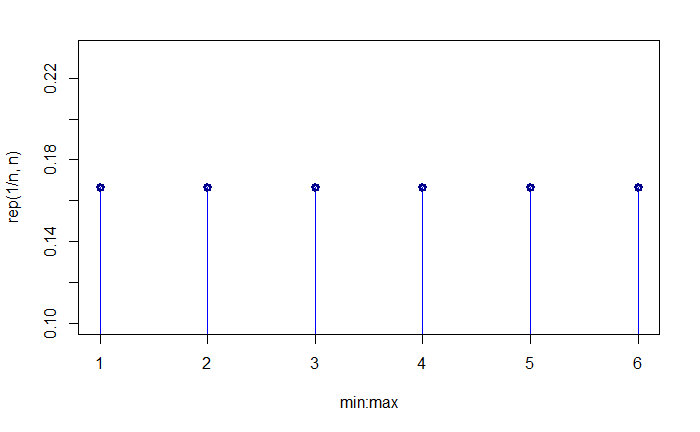

```r
min = 1
max = 6
n = max - min + 1
plot(min:max, rep(1/n, n), type = "h", col = "blue")
points(min:max, rep(1 / n, n), type = "p", lwd = 3, col = "darkblue")
```

### Example 2:

Toss a coin 10 times.

```r
sample(c("H","T"), size = 10, replace = TRUE)
```

```
 [1] "T" "H" "T" "H" "H" "H" "H" "H" "T" "H"
```

### Example 3:

Pick 6 of 49 (a lottery) numbers.

```r
sample(1:49, size = 6)
```

```
[1] 10 44 37 30 28 27
```

Probability mass function (pmf)

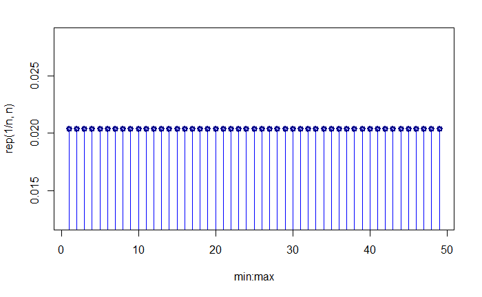

```r
min = 1
max = 49
n = max - min + 1
plot(min:max, rep(1/n, n), type = "h", col = "blue")
points(min:max, rep(1 / n, n), type = "p", lwd = 3, col = "darkblue")
```

### Example 4:

Pick 5 card.

```r
cards = paste(rep(c("A",2:10,"J","Q","K"), 4),
              c("H","D","S","C"))
cards
```

```
 [1] "A H"  "2 D"  "3 S"  "4 C"  "5 H"  "6 D"  "7 S"  "8 C"  "9 H"  "10 D" "J S"  "Q C"  "K H"  "A D"  "2 S"
[16] "3 C"  "4 H"  "5 D"  "6 S"  "7 C"  "8 H"  "9 D"  "10 S" "J C"  "Q H"  "K D"  "A S"  "2 C"  "3 H"  "4 D"
[31] "5 S"  "6 C"  "7 H"  "8 D"  "9 S"  "10 C" "J H"  "Q D"  "K S"  "A C"  "2 H"  "3 D"  "4 S"  "5 C"  "6 H"
[46] "7 D"  "8 S"  "9 C"  "10 H" "J D"  "Q S"  "K C"
```

```r
sample(x = cards, size = 5)
```

```
[1] "6 D"  "10 H" "4 C"  "10 S" "9 H"
```

**rep** - replicates the values in x

### Example 5:

Roll 2 die

```r
dice = as.vector(outer(1:6,1:6,paste)); dice
```

```
 [1] "1 1" "2 1" "3 1" "4 1" "5 1" "6 1" "1 2" "2 2" "3 2" "4 2" "5 2" "6 2" "1 3" "2 3" "3 3" "4 3" "5 3" "6 3"
[19] "1 4" "2 4" "3 4" "4 4" "5 4" "6 4" "1 5" "2 5" "3 5" "4 5" "5 5" "6 5" "1 6" "2 6" "3 6" "4 6" "5 6" "6 6"
```

**outer** - The product of the arrays X and Y is the array A with dimension c(dim(X), dim(Y))

```r
sample(x = dice, size = 5, replace = TRUE)
```

```
[1] "2 1" "2 3" "1 6" "1 4" "2 6"
```

## [Bernoulli distribution (Бернулиево разпределение)](https://en.wikipedia.org/wiki/Bernoulli_distribution)

Bernoulli distribution, named after Swiss mathematician Jacob Bernoulli is the probability distribution of a random variable which takes the value 1 with probability p and the value 0 with probability q = 1 - p. Частен случай на Биномно разпределената случайна величина.

## [Binomial distribution (Биномно разпределение)](https://en.wikipedia.org/wiki/Binomial_distribution)

The binomial distribution with parameters n and p is the discrete probability distribution of the number of successes in a sequence of n independent experiments.  
Нека имаме n независими опити, с вероятност за “Успех” при всеки от тях p.  
Тогава X - боря на “Успехите” при тези n опита е биномнo разпределена случайна величина  
**X ~ Bi(n, p)**

```r
n = 1 # Брой опити
p = 0.5 # Вероятност за "Успех" при всеки опит
```

```r
rbinom(1, n, p) # Бернулиево разпределена сл. в.
```

```
[1] 1
```

```r
n = 10 # Брой опити
p = 0.5 # Вероятност за "Успех" при всеки опит
rbinom(1, n, p) # Биномно разпределена сл.в.
```

```
[1] 5
```

Генерира ни 100 числo, които са Биномно разпределени и всяко от тях представлява - 10 опит с вероятност за “Успех” 0.5

```r
n = 10 # Брой опити
p = 0.5 # Вероятност за "Успех" при всеки опит
rbinom(100, n, p) # Биномно разпределена сл.в.
```

```
  [1] 5 3 6 6 6 4 7 3 3 4 6 4 4 4 3 4 6 4 5 6 3 4 6 3 3 7 6 4 5 7 3 2 7 2 4 6 3 4 3 3 6 5 6 4 5 4 5 5 6 5 4 4 3
 [54] 5 2 4 4 6 5 5 8 5 6 6 4 6 6 6 5 4 5 7 7 5 4 5 6 6 5 6 4 4 6 7 5 6 6 5 7 5 2 4 5 5 6 5 6 3 4 4
```

```r
n = 10
p = 3/5
rbinom(1, 10, p)
```

```
[1] 7
```

```r
rbinom(10, n, p)
```

```
 [1] 6 4 8 8 6 3 6 6 7 7
```

```r
n = 10
p = 0.5
```

Генерира едно число, което представлява - 10 опита с вероятност за “Успех” 0.5

```r
rbinom(1, n, p)
```

```
[1] 5
```

Генерира пет числа, които представляват - 10 опита с вероятност за “Успех” 0.5

```r
rbinom(5, n, p)
```

```
[1] 4 7 4 4 5
```

### Example:

Генерира 100 числа, които представляват - 5 опита с вероятност за “Успех” 0.25

```r
n = 5
p = 0.25
x = rbinom(100, n, p)
x
```

```
  [1] 3 2 1 0 0 2 2 0 3 1 2 0 1 1 0 2 1 2 2 0 1 1 0 0 2 1 2 2 3 3 3 0 0 1 3 1 2 0 0 0 1 2 2 1 1 3 2 2 1 0 1 1 2
 [54] 1 1 1 2 1 2 1 0 1 0 3 2 2 1 2 1 1 1 2 2 2 3 0 2 0 2 1 2 1 1 1 0 0 2 1 1 1 2 0 1 1 1 0 1 3 2 3
```

```r
table(x)
```

```
x
 0  1  2  3
22 37 30 11
```

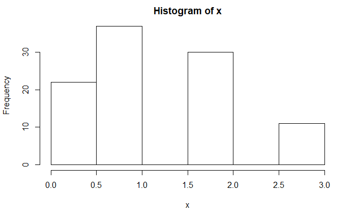

```r
hist(x)
```

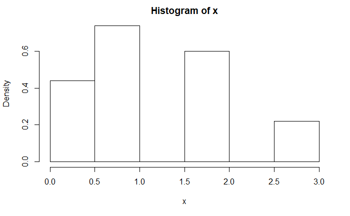

```r
hist(x, probability = TRUE)
```

Probability mass function (pmf)  
**dbinom** - gives the density

```r
n = 5
p = 0.25
x = rbinom(100, n, p)
hist(x, probability = TRUE)
xvals = 0:n
points(xvals, dbinom(xvals,n,p), type = "h", lwd = 3, col = "blue")
```

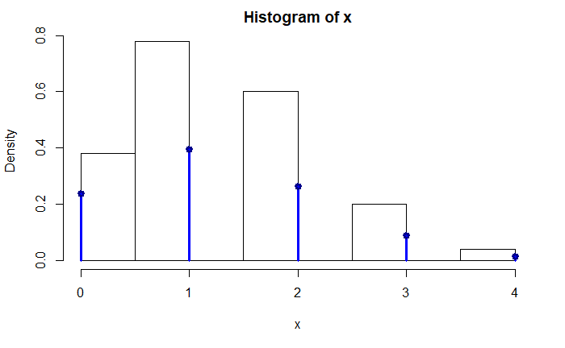

```r
points(xvals, dbinom(xvals,n,p), type = "p", lwd = 3, col = "darkblue")
```

```r
?points
```

“h” for histogram-like vertical lines  
“p” for points  
“l” for lines  
“b” for both points and lines  
“c” for empty points joined by lines  
“o” for overplotted points and lines  
“s” and “S” for stair steps

```r
n = 5
p = 0.25
x = rbinom(100, n, p)
hist(x, probability = TRUE)
xvals = 0:n
?points
points(xvals, dbinom(xvals,n,p), type = "h", lwd = 3)
```

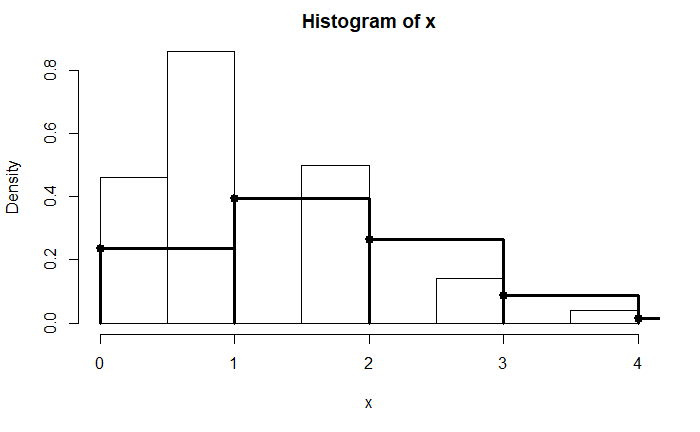

```r
points(xvals, dbinom(xvals,n,p), type = "p", lwd = 3)
points(xvals, dbinom(xvals,n,p), type = "s", lwd = 3)
```

“n” does not produce any points or lines.

### Example:

Генерира 100 числа, които представляват - 15 опита с вероятност за “Успех” 0.25

```r
n = 15
p = 0.25
x = rbinom(100, n, p); x
```

```
  [1] 6 2 6 1 3 5 5 7 4 5 4 3 1 2 6 4 4 7 2 5 2 5 4 6 5 4 2 2 6 3 3 4 6 5 5 5 3 2 4 1 4 7 3 4 6 5 5 2 5 7 2 3 3
 [54] 2 1 7 1 3 2 2 4 5 2 8 3 4 4 7 4 5 5 5 3 4 6 6 6 3 4 3 5 3 4 2 5 4 1 2 5 3 3 4 7 2 5 3 3 8 4 3
```

```r
table(x)
```

```
x
 1  2  3  4  5  6  7  8
 6 16 19 20 20 10  7  2
```

```r
hist(x, probability = TRUE)
xvals = 0:n
points(xvals, dbinom(xvals,n,p), type = "h", lwd = 3, col = "blue")
```

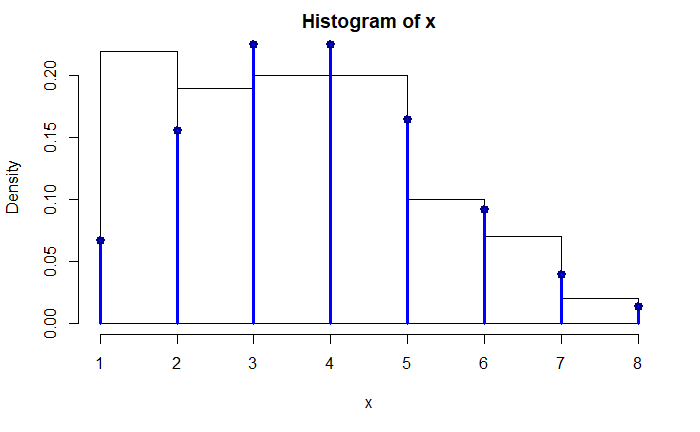

```r
points(xvals, dbinom(xvals,n,p), type = "p", lwd = 3, col = "darkblue")
```

### Example:

Генерира 100 числа, които представляват - 50 опита с вероятност за “Успех” 0.25

```r
n = 50
p = 0.25
x = rbinom(100, n, p)
table(x)
```

```
x
 6  7  8  9 10 11 12 13 14 15 16 17 18 19 20
 3  2  1 10 13 13 16 12  9  7  6  4  2  1  1
```

```r
hist(x, probability = TRUE)
xvals = 0:n
points(xvals, dbinom(xvals,n,p), type = "h", lwd = 3, col = "blue")
```

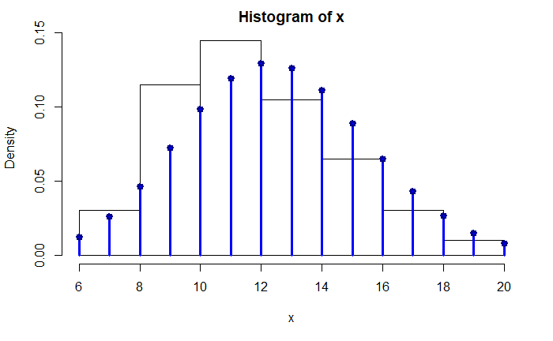

```r
points(xvals, dbinom(xvals,n,p), type = "p", lwd = 3, col = "darkblue")
```

```r
n = 5
p = 0.25
xvals = 0:n # seq(from = 0, to = n, by = 1)
y = dbinom(xvals, n, p)
plot(0:n, y, type = "s", col = "darkblue")
points(xvals, dbinom(xvals,n,p), type = "h", lwd = 3, col = "blue")
```

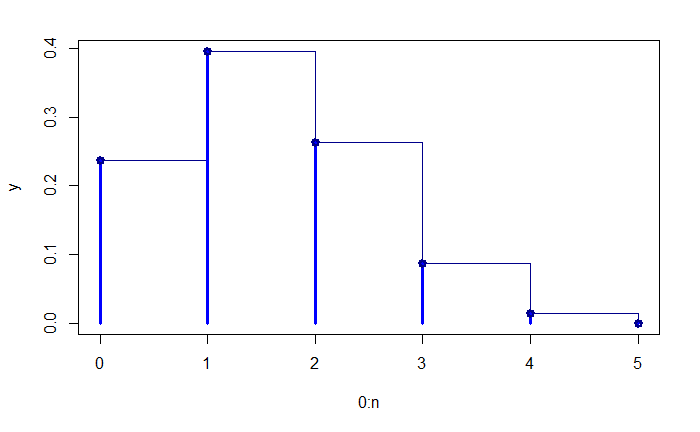

```r
points(xvals, dbinom(xvals,n,p), type = "p", lwd = 3, col = "darkblue")
```

### Example

```r
pbinom(2, 5, 0.3)
```

```
[1] 0.837
```

P(X > 2)

```r
pbinom(2, 5, 0.3, lower.tail = FALSE)
```

```
[1] 0.163
```

**qbinom** - gives the quantile function qbinom(p, size, prob, lower.tail = TRUE) ### Example

```r
qbinom(0.83, 5, 0.3)
```

```
[1] 2
```

```r
qbinom(0.83, 5, 0.3, lower.tail = FALSE)
```

```
[1] 1
```

## [Geometric distribution (Геометрично разпределение)](https://en.wikipedia.org/wiki/Geometric_distribution)

The probability distribution of the number Y = X − 1 of failures before the first success.  
Нека имаме независими повторения на един и същи опити, с вероятност за “Успех” при всеки от тях p.  
Tогава X - броя на опитите до първия “Успех” е геометрично разпределена случайна величина  
**X ~ Ge(p)**  
[link](https://stat.ethz.ch/R-manual/R-devel/library/stats/html/Geometric.html)  
**dgeom**(x, prob)  
**pgeom**(q, prob, lower.tail = TRUE)  
**qgeom**(p, prob, lower.tail = TRUE)  
**rgeom**(n, prob)  
Частен случай на Отрицателно биномното разпределение.

### Example

Едно число, което представлява - броя на опитите до първия “Успех”, ако вероятността ни за успех при един опит е 0.2

```r
rgeom(1, 0.2)
```

```
[1] 0
```

Десет числа, които представляват - броя на опитите до първия “Успех”, ако вероятността ни за успех при един опит е 0.2

```r
rgeom(10, 0.2)
```

```
 [1] 2 0 7 3 4 7 0 4 5 1
```

### Example

Моделира броя неуспехи до първата се паднала 6-ца.

```r
p = 1/6
x = rgeom(100, p); x
```

```
  [1] 11  1  2  3  1  2  0  1  2 11 17  0  9  3  4  9  0  3  5  7  5  3  0  7  0 14  7  0  1  0  1  1  0  8  2
 [36]  0  0  8  2  0  3 25  7  0  1  0  0  3  7  7  0  6  4  2  0  6  2  1  0  1  0  1  6 18  8  0  7  0  0  3
 [71]  4  1  4  4  7  5 10  1  8  3  6  5  4  2 15  2  3  8  3  2  9  4 11 17  4  5  2  0  4 22
```

```r
hist(x, probability = TRUE)
xvals = 0:100
points(xvals, dgeom(xvals,p), type = "h", lwd = 3, col = "blue")
```

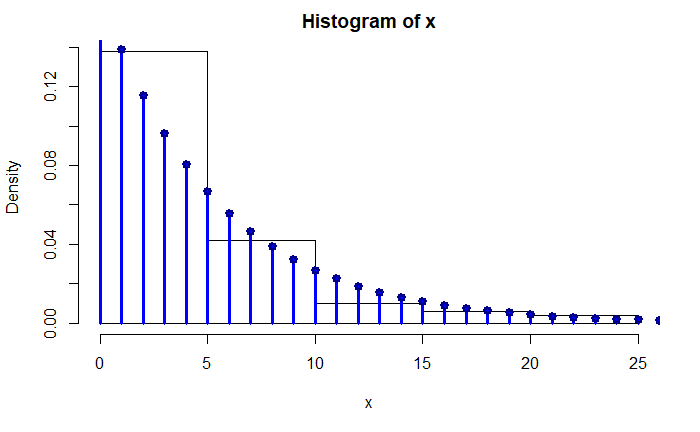

```r
points(xvals, dgeom(xvals,p), type = "p", lwd = 3, col = "darkblue")
```

```r
p = 1/6
pgeom(5, p)
```

```
[1] 0.665
```

```r
pgeom(10, p) - pgeom(5, p)
```

```
[1] 0.2
```

```r
qgeom(0.5, p)
```

```
[1] 3
```

## [Negative binomial distribution (Отрицателно биномно разпределение)](https://en.wikipedia.org/wiki/Negative_binomial_distribution)

Discrete probability distribution of the number of successes in a sequence of independent and identically distributed Bernoulli trials before a specified number of successes occurs.  
Нека имаме независими повторения на един и същи опити, с вероятност за “Успех” при всеки от тях p.  
Тогава X - броя на неуспехите до n-тия “Успех” е отрицателно биномно разпределена случайна величина  
**X ~ NBi(n, p)**  
[link](https://stat.ethz.ch/R-manual/R-devel/library/stats/html/NegBinomial.html)  
**dnbinom**(x, size, prob)  
**pnbinom**(q, size, prob, lower.tail = TRUE)  
**qnbinom**(p, size, prob, lower.tail = TRUE)  
**rnbinom**(n, size, prob)  
### Example: Едно число, което представлява - броя на неуспехите до 5тия “Успех”, ако вероятността ни за успех при един опит е 0.2

```r
rnbinom(1, 5, 0.2)
```

```
[1] 31
```

Десет числа, които представляват- броя на неуспехите до 5тия “Успех”, ако вероятността ни за успех при един опит е 0.2

```r
rnbinom(10, 5, 0.2)
```

```
 [1] 17 26 27 26 22 11 19 28  8 20
```

### Example:

Ако имаме зарче и наречем “Успех” хвърлянето на 6. То X ще ни моделира - броя неуспехи до 3тото падане на 6ца

```r
k = 3
p = 1/6
x = rnbinom(100, k, p); x
```

```
  [1]  2 22 18 19 21 17 21  9  1  8 22  4 10 22 36 20 22 13 15 15  3  5  7 14 17  3 14 21  1 34 12 22 13 72 26
 [36]  7  7  3 20 17  9 12 10  2 11 13 15 10 10 14 40 11 22  1  4 21  9  8  9  5  4 15  8  9 23  0 19 17 14 12
 [71] 11 34 17  6  6 28  8 15 11 21  5  8 22  3 15 28 21 27 16 14 24  5 16 27 13 19 27 38 19 13
```

```r
hist(x, probability = TRUE)
xvals = 0:100
points(xvals, dnbinom(xvals,k,p), type = "h", lwd = 3, col = "blue")
```

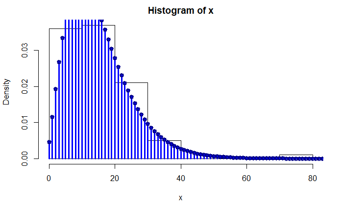

```r
points(xvals, dnbinom(xvals,k,p), type = "p", lwd = 3, col = "darkblue")
```

```r
k = 3
p = 1/6
pnbinom(5, k, p)
```

```
[1] 0.135
```

```r
pnbinom(10, k, p) - pnbinom(4, k, p)
```

```
[1] 0.276
```

```r
pnbinom(0.5, k, p)
```

```
[1] 0.00463
```

## [Hypergeometric distribution (Хипергеометрично разпределение)](https://en.wikipedia.org/wiki/Hypergeometric_distribution)

[link](https://stat.ethz.ch/R-manual/R-devel/library/stats/html/Hypergeometric.html)  
Зависими опити  
**X ~ HG(m, n, k)**  
m - the number of white balls in the urn  
n - the number of black balls in the urn  
k - the number of balls drawn from the urn.  
**dhyper**(x, m, n, k)  
**phyper**(q, m, n, k, lower.tail = TRUE)  
**qhyper**(p, m, n, k, lower.tail = TRUE)  
**rhyper**(nn, m, n, k)

### Example

Едно число, което представлява - броя на извадените бели топки от урната, ако в началото на опита в урната е имало 10 бели и 12 черни топки и сме изтеглили 15 топки, без връщане.

```r
rhyper(1, 10, 12, 15)
```

```
[1] 7
```

Десет числа, които представляват - броя на извадените бели топки от урната, ако в началото на опита в урната е имало 10 бели и 12 черни топки и сме изтеглили 15 топки, без връщане, т.е. вероятността за бяла топка се е променяла при всяко теглене.

```r
rhyper(10, 10, 12, 15)
```

```
 [1] 8 8 6 6 7 8 6 5 8 8
```

```r
m = 20 # the number of white balls in the urn
n = 12 # the number of black balls in the urn
k = 15 # the number of balls drawn from the urn.
x = rhyper(100, m, n, k); x
```

```
  [1]  7  9  8 10  9  8  8  8  9  9 10 10  9 10  9 10 10  8  9  8 11 11  9  8 12  9 11 10  8 11  9  7 11  9 13
 [36] 11  8 10  9  6 10  8 11  9  9  9 11 10 11  8 11  6 10 10  9 11  9  9  9 10  9 12 12  7  9 11 10  9 11  9
 [71]  9  8  9  7 11  9 10  9  9  9 11  9 11 10 10 11  9 10 11  7 10  9 11  8 10  9  9 10  8 10
```

```r
hist(x, probability = TRUE)
xvals = 0:100
points(xvals, dhyper(xvals,m, n, k), type = "h", lwd = 3, col = "blue")
```

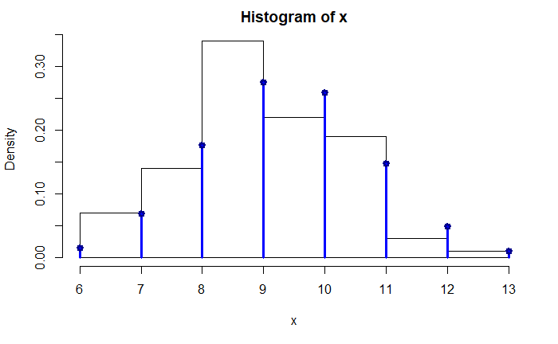

```r
points(xvals, dhyper(xvals,m, n, k), type = "p", lwd = 3, col = "darkblue")
```

## [Poisson distribution (Поасоново разпределение)](https://en.wikipedia.org/wiki/Poisson_distribution)

Named after French mathematician Siméon Denis Poisson. Distribution that expresses the probability of a given number of events occurring in a fixed interval of time or space if these events occur with a known constant rate and independently of the time since the last event.  
**X ~ Po(lambda)**  
[link](https://stat.ethz.ch/R-manual/R-devel/library/stats/html/Poisson.html)  
**dpois**(x, lambda)  
**ppois**(q, lambda, lower.tail = TRUE)  
**qpois**(p, lambda, lower.tail = TRUE)  
**rpois**(n, lambda)

```r
lambda = 20 # arived cars
x = rpois(100, lambda); x
```

```
  [1] 24 20 19 24 24 16 17 19 23 26 17 20 20 22 23 24 23 24 22 27 16 12 17 27 19 14 32 21 27 18 19 15 14 29 27
 [36] 11 15 24 23 21 23 22 23 12 22 18 14 14 13 17 19 20 18 17 16 23 18 29 17 17 21 18 17 24 20 23 18 33 13 15
 [71] 14 14 14 18 28 26 13 24 24 15 19 22 11 16 21 19 24 24 25 22 16 24 15 16 30 23 30 23 22 18
```

```r
hist(x, probability = TRUE)
xvals = 0:100
points(xvals, dpois(xvals, lambda), type = "h", lwd = 3, col = "blue")
```

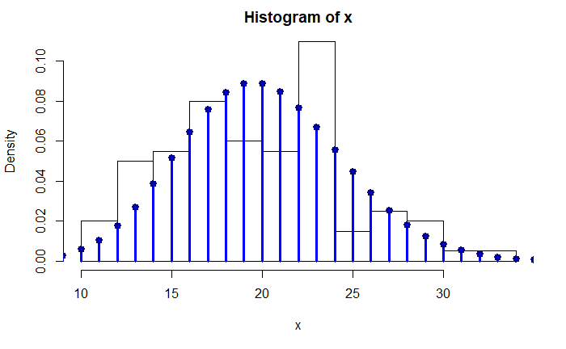

```r
points(xvals, dpois(xvals, lambda), type = "p", lwd = 3, col = "darkblue")
```

# Continuous Ditributions

- Probability density function (pdf)
- Cumulative distribution function (cmf)
- Moments
- - First moment - Mean - EX
- - Second moment - Variance - VarX
- - Third moment - Skewness
- - Fourth moment - Kurtosis

## Uniform continuous distribution (Непрекъснато равномерно разпределение)

**runif** - generates n random numbers with uniform continuous distribution runif(n, min = 0, max = 1)

```r
runif(1,min = 0,max = 2)
```

```
[1] 0.52
```

```r
runif(5,min = 0,max = 2)
```

```
[1] 0.137 1.724 0.555 0.154 1.687
```

You can see that every time it generates a new numbers

```r
runif(5,min = 0,max = 2)
```

```
[1] 1.739 1.057 0.759 1.938 1.472
```

```r
runif(5,min = 0,max = 2)
```

```
[1] 1.332 0.941 1.329 1.885 1.407
```

```r
runif(5,min = 0,max = 2)
```

```
[1] 0.219 1.037 1.297 0.026 0.598
```

But if you want to save your work and continue later or send it to a friend or you need someone to check it. It is usefull to always generate same random numbers.  
**set.seed()** - state for random number generation in R

```r
?set.seed
set.seed(10)
runif(5,min = 0,max = 2)
```

```
[1] 1.015 0.614 0.854 1.386 0.170
```

```r
set.seed(10)
runif(5,min = 0,max = 2)
```

```
[1] 1.015 0.614 0.854 1.386 0.170
```

```r
set.seed(10)
runif(5,min = 0,max = 2)
```

```
[1] 1.015 0.614 0.854 1.386 0.170
```

```r
x = runif(100); x
```

```
  [1] 0.2254 0.2745 0.2723 0.6158 0.4297 0.6517 0.5677 0.1135 0.5959 0.3580 0.4288 0.0519 0.2642 0.3988 0.8361
 [16] 0.8647 0.6154 0.7751 0.3556 0.4058 0.7066 0.8383 0.2396 0.7708 0.3559 0.5356 0.0931 0.1698 0.8998 0.4226
 [31] 0.7477 0.8227 0.9547 0.6854 0.5005 0.2755 0.2289 0.0144 0.7290 0.2499 0.1612 0.0170 0.4861 0.1029 0.8015
 [46] 0.3543 0.9364 0.2459 0.4731 0.1916 0.5832 0.4595 0.4674 0.3998 0.5053 0.0319 0.1145 0.4689 0.3970 0.8336
 [61] 0.7611 0.5734 0.4475 0.0838 0.2191 0.0756 0.5344 0.6414 0.5257 0.0393 0.5459 0.3728 0.9613 0.2573 0.2080
 [76] 0.8614 0.4644 0.2229 0.6235 0.2036 0.0197 0.7980 0.2743 0.1666 0.1702 0.4885 0.7114 0.5919 0.5172 0.3816
 [91] 0.8348 0.2490 0.5406 0.7438 0.0300 0.3443 0.0613 0.3690 0.4076 0.9143
```

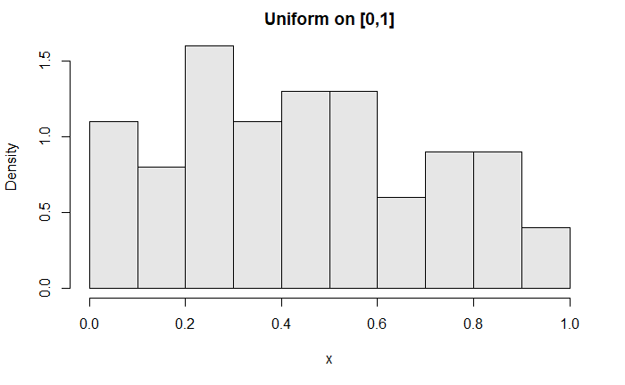

```r
hist(x,
     probability = TRUE,
     col = gray(.9),
     main = "Uniform on [0,1]")
```

**dunif** - gives the density dunif(x, min = 0, max = 1)

```r
x = runif(100); x
```

```
  [1] 0.8887 0.9837 0.4772 0.6935 0.4257 0.7842 0.8427 0.1835 0.5285 0.7029 0.9133 0.2592 0.7926 0.6145 0.7006
 [16] 0.1079 0.3339 0.3241 0.5654 0.2032 0.2197 0.6331 0.3525 0.8569 0.9507 0.8880 0.0469 0.7690 0.2302 0.3152
 [31] 0.2827 0.7132 0.8621 0.1063 0.5503 0.6484 0.2348 0.0763 0.9231 0.1472 0.8224 0.4135 0.6125 0.0681 0.9041
 [46] 0.8795 0.1971 0.0695 0.1573 0.3335 0.1801 0.1465 0.2906 0.9361 0.1025 0.7234 0.5164 0.4119 0.4133 0.7620
 [61] 0.2592 0.7632 0.9824 0.6701 0.5899 0.5631 0.7618 0.7453 0.7078 0.9868 0.4516 0.1182 0.2386 0.4705 0.3523
 [76] 0.3386 0.1273 0.4241 0.4733 0.5277 0.6270 0.8760 0.6792 0.7241 0.1818 0.0779 0.0722 0.0541 0.5173 0.8141
 [91] 0.4490 0.5589 0.2799 0.8901 0.7158 0.2231 0.5359 0.6625 0.8481 0.1492
```

```r
hist(x,
     probability = TRUE,
     col = gray(.9),
     main = "Uniform on [0,1]")
dunif(x, min = 0, max = 1) # Calculated by the formula 1/(max - min) inside the interval
```

```
  [1] 1 1 1 1 1 1 1 1 1 1 1 1 1 1 1 1 1 1 1 1 1 1 1 1 1 1 1 1 1 1 1 1 1 1 1 1 1 1 1 1 1 1 1 1 1 1 1 1 1 1 1 1 1
 [54] 1 1 1 1 1 1 1 1 1 1 1 1 1 1 1 1 1 1 1 1 1 1 1 1 1 1 1 1 1 1 1 1 1 1 1 1 1 1 1 1 1 1 1 1 1 1 1
```

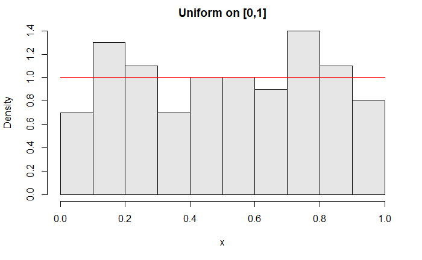

```r
curve(dunif(x, 0, 1),
      add = TRUE,
      col = 2)
```

**punif** - gives the probability  
punif(q, min = 0, max = 1, lower.tail = TRUE)

### Example:

X ~ Uniform(0,1)  
P(X <= 0.2)

```r
punif(0.2, 0, 1)
```

```
[1] 0.2
```

P(X > 0.2)

```r
punif(0.2, 0, 1, lower.tail = FALSE)
```

```
[1] 0.8
```

**qunif** - gives the quantile function qunif(p, min = 0, max = 1, lower.tail = TRUE)

```r
qunif(0.6, 0, 1)
```

```
[1] 0.6
```

### Example:

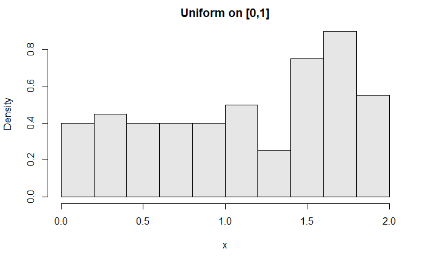

```r
x = runif(100, min = 0, max = 2)
hist(x,
     probability = TRUE,
     col = gray(.9),
     main = "Uniform on [0,1]")
```

```r
x = runif(100, min = 0, max = 2)
hist(x,
     probability = TRUE,
     col = gray(.9),
     main = "Uniform on [0,1]")
dunif(x, min = 0, max = 2) # Calculated by the formula 1/(max - min) inside the interval
```

```
  [1] 0.5 0.5 0.5 0.5 0.5 0.5 0.5 0.5 0.5 0.5 0.5 0.5 0.5 0.5 0.5 0.5 0.5 0.5 0.5 0.5 0.5 0.5 0.5 0.5 0.5 0.5
 [27] 0.5 0.5 0.5 0.5 0.5 0.5 0.5 0.5 0.5 0.5 0.5 0.5 0.5 0.5 0.5 0.5 0.5 0.5 0.5 0.5 0.5 0.5 0.5 0.5 0.5 0.5
 [53] 0.5 0.5 0.5 0.5 0.5 0.5 0.5 0.5 0.5 0.5 0.5 0.5 0.5 0.5 0.5 0.5 0.5 0.5 0.5 0.5 0.5 0.5 0.5 0.5 0.5 0.5
 [79] 0.5 0.5 0.5 0.5 0.5 0.5 0.5 0.5 0.5 0.5 0.5 0.5 0.5 0.5 0.5 0.5 0.5 0.5 0.5 0.5 0.5 0.5
```

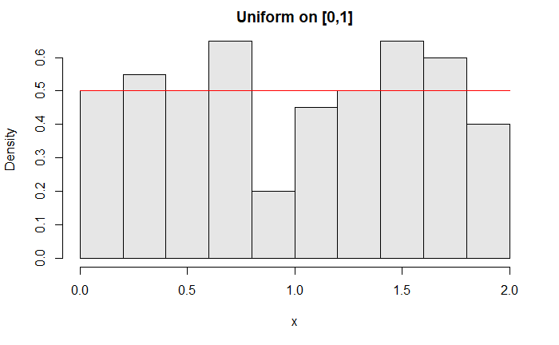

```r
                           # 1/(2 - 0) = 1/2 = 0.5
curve(dunif(x, 0, 2),
      add = TRUE,
      col = 2)
```

# [Exponential distribution (Експоненциално разпределение)](https://en.wikipedia.org/wiki/Exponential_distribution)

[link](https://stat.ethz.ch/R-manual/R-devel/library/stats/html/Exponential.html)

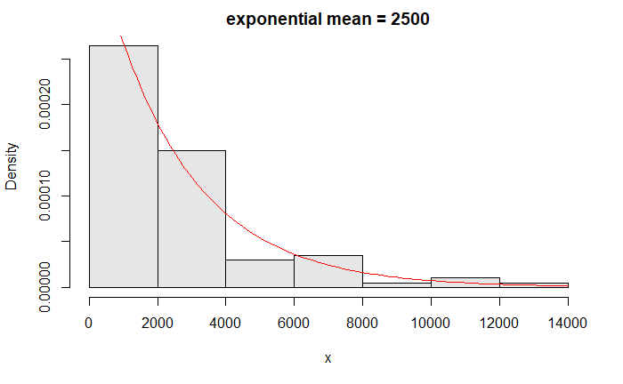

```r
x = rexp(100, 1/2500)
hist(x, probability = TRUE, col = gray(.9), main = "exponential mean = 2500")
curve(dexp(x, 1/2500), add = TRUE, col = "red")
```

# [Normal distribution (Нормално разпределение)](https://en.wikipedia.org/wiki/Normal_distribution)

[link](https://stat.ethz.ch/R-manual/R-devel/library/stats/html/Normal.html)

```r
rnorm(1, mean = 100, sd = 16)
```

```
[1] 96
```

```r
rnorm(1, mean = 280, sd = 10)
```

```
[1] 306
```

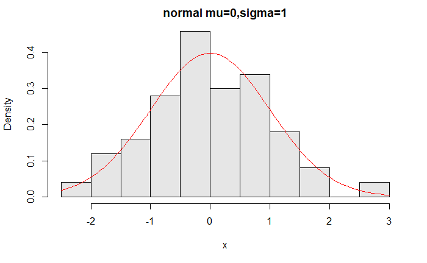

```r
x = rnorm(100)
hist(x,probability = TRUE, col = gray(.9), main = "normal mu=0,sigma=1")
curve(dnorm(x), add = TRUE, col = "red")
```

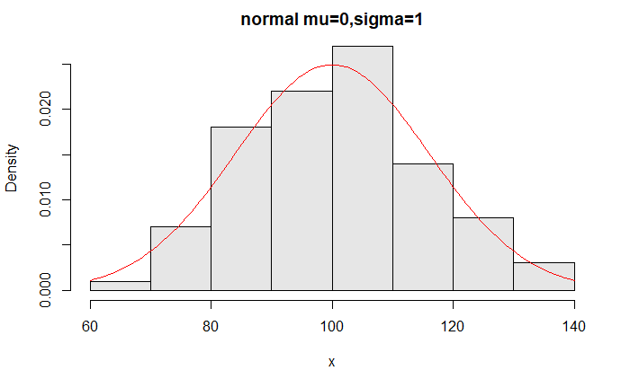

```r
x = rnorm(100, mean = 100, sd = 16)
hist(x, probability = TRUE, col = gray(.9), main = "normal mu=0,sigma=1")
curve(dnorm(x, mean = 100, sd = 16), add = TRUE, col = "red")
```

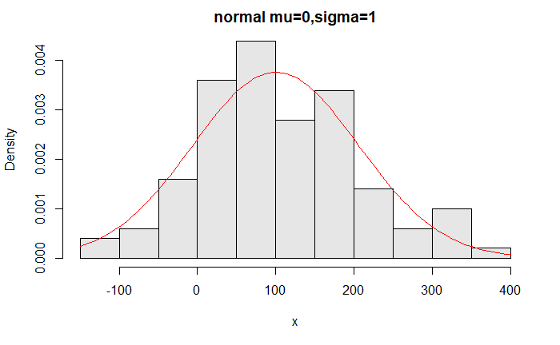

```r
x = rnorm(100, mean = 100, sd = 106)
hist(x, probability = TRUE, col = gray(.9), main = "normal mu=0,sigma=1")
curve(dnorm(x, mean = 100, sd = 106), add = TRUE, col = "red")
```

## z scores

```r
mean.x = 100
sd.x = 16
x = rnorm(5, mean.x, sd.x); x
```

```
[1]  91.1  89.7  88.4 100.2 115.4
```

```r
z.score = (x - mean.x) / sd.x; z.score
```

```
[1] -0.5564 -0.6433 -0.7226  0.0121  0.9613
```

# [Student’s t-distribution (t разпределение)](https://en.wikipedia.org/wiki/Student%27s_t-distribution)

[link](https://stat.ethz.ch/R-manual/R-devel/library/stats/html/TDist.html)

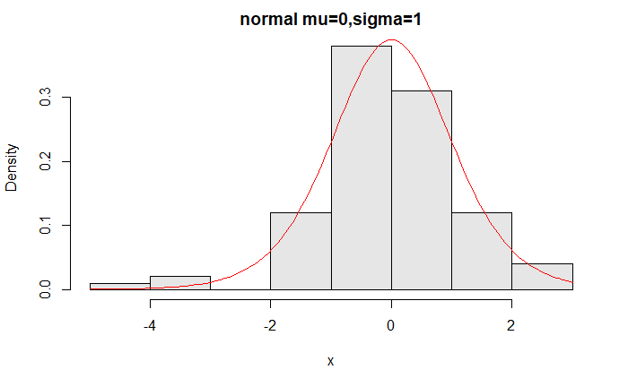

```r
x = rt(100, 10)
hist(x, probability = TRUE, col = gray(.9), main = "normal mu=0,sigma=1")
curve(dt(x, 10), add=TRUE, col = "red")
```

# [Chi-squared distribution (Хи квадрат разпределение)](https://en.wikipedia.org/wiki/Chi-squared_distribution)

[link](https://stat.ethz.ch/R-manual/R-devel/library/stats/html/Chisquare.html)  
Ако X1 ,X2, …, Xn са независими, еднакво стандартно нормално разпределени случайни величини, то сумата от квадратите им e X1^2 + X2^2 + .. + Xn^2 ~ X^2(n)

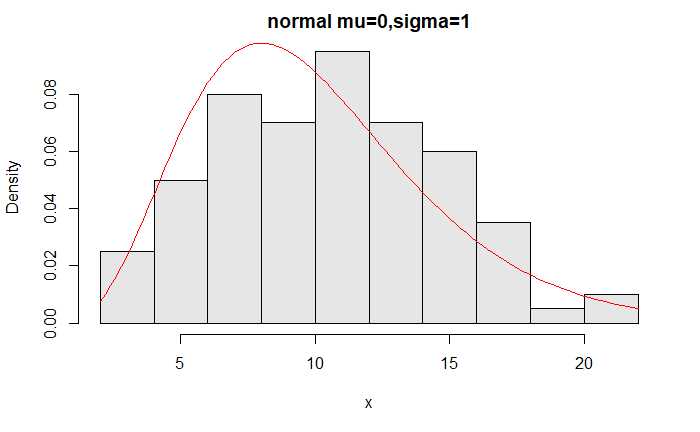

```r
x = rchisq(100, 10)
hist(x, probability = TRUE, col = gray(.9), main = "normal mu=0,sigma=1")
curve(dchisq(x, 10), add = TRUE, col = "red")
```

```r
pnorm(0.7)
```

```
[1] 0.758
```

```r
pnorm(0.7, 1, 1)
```

```
[1] 0.382
```

```r
pnorm(0.7, lower.tail = FALSE)
```

```
[1] 0.242
```

```r
qnorm(0.75)
```

```
[1] 0.674
```

# A bootstrap sample

```r
faithful
```

|  | eruptions | waiting |
| --- | --- | --- |
| 1 | 3.60 | 79 |
| 2 | 1.80 | 54 |
| 3 | 3.33 | 74 |
| 4 | 2.28 | 62 |
| 5 | 4.53 | 85 |
| 6 | 2.88 | 55 |
| 7 | 4.70 | 88 |
| 8 | 3.60 | 85 |
| 9 | 1.95 | 51 |
| 10 | 4.35 | 85 |

[output cut: 262 more lines]

```r
names(faithful)
```

```
[1] "eruptions" "waiting"
```

```r
sample(faithful$eruptions, 10, replace = TRUE)
```

```
 [1] 4.75 3.82 4.37 4.50 3.88 2.00 1.83 1.87 4.23 2.88
```

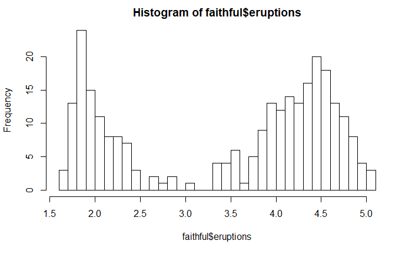

```r
hist(faithful$eruptions, breaks = 25) # the dataset
```

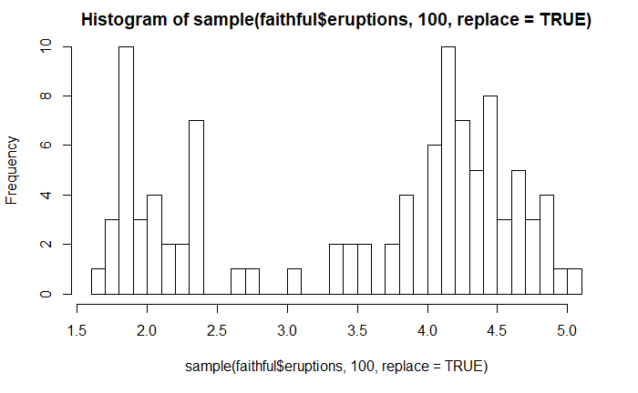

```r
hist(sample(faithful$eruptions, 100, replace = TRUE), breaks = 25)
```

# Problems - Verzani - page 47

## Problem 6.1

```r
x = runif(10, min = 0, max = 10); x
```

```
 [1] 9.162 8.537 4.493 4.512 4.181 7.729 2.335 9.358 0.632 4.430
```

```r
min(x)
```

```
[1] 0.632
```

```r
max(x)
```

```
[1] 9.36
```

## Problem 6.2

```r
x = rnorm(10, 5, 5); x
```

```
 [1]  9.598  3.563 -0.206  1.174  0.208  4.760 11.920 -3.277  6.352  2.068
```

```r
sum(x < 0)
```

```
[1] 2
```

```r
pnorm(0, 5, 5)
```

```
[1] 0.159
```

## Problem 6.3

```r
x = rnorm(100, 100, 10); x
```

```
  [1] 114.3  90.9  99.4  91.9 111.4  86.3  91.0 107.0 106.6  91.6 105.7  93.1  93.0  86.8 106.0  96.5  91.6
 [18]  98.5  99.5  88.9 117.6 111.8 103.5  90.5  96.4  90.7  90.2  97.5 100.4 105.0 107.9  95.4  87.8  93.7
 [35] 106.9 120.6 113.3  94.9 108.3 103.2 109.6  98.5  93.2 114.8 103.9  84.7 116.9 108.3  96.0  95.5  98.9
 [52]  90.3  98.3 102.6  95.4 103.6  92.8  98.9  98.3  97.4 106.7 109.7  94.0  80.2  93.5  94.3  96.0  96.9
 [69] 108.6  77.8  97.4 104.8 101.0  91.0  93.7 113.2 101.5 115.7 121.4  87.5 103.2  99.6  96.0  98.1 118.1
 [86] 101.6  93.3 107.8  84.2  87.6 108.7  94.6  92.6 115.2 104.0  88.7  93.6 118.7  95.0  86.7
```

```r
sum(x < 80 | x > 120)
```

```
[1] 3
```

## 6.4

```r
x = rbinom(1, 50, 0.5); x
```

```
[1] 20
```

```r
x = rbinom(50, 1, 0.5)
sum(x)
```

```
[1] 26
```

## 6.5

```r
x = rbinom(1, 100, 1/6); x
```

```
[1] 14
```

```r
sum(x = 6)
```

```
[1] 6
```

## 6.6

```r
x = sample(1:49, 6, replace = FALSE); x
```

```
[1] 21 34 42  4  7 23
```

```r
min(x)
```

```
[1] 4
```

```r
max(x)
```

```
[1] 42
```

## 6.7

```r
qnorm(0.05, 0, 1)
```

```
[1] -1.64
```

## 6.8

```r
qnorm(0.025, 0, 1)
```

```
[1] -1.96
```

```r
qnorm(1-0.025, 0, 1)
```

```
[1] 1.96
```

# Tasks - moodle

## Задача 1

Хвърлят се 30 зара. Каква е вероятността да се паднат по-малко от 5 шестици? Сравнете теоретичната вероятност с експериментални данни. Можем да твърдим, че с вероятност 0.75 ще се паднат повече от колко шестици?

```r
# Хвърляме 30 зара
dices = sample(1:6, 30, replace = TRUE); dices
```

```
 [1] 6 5 1 5 6 2 1 4 1 2 6 4 1 3 3 5 4 5 4 3 3 6 4 1 6 3 4 3 1 3
```

```r
table(dices)
```

```
dices
1 2 3 4 5 6
6 2 7 6 4 5
```

```r
# X - брой паднали се шестици
# X ~ Binom(30, 1/6)
# P(X < 5) = P(X <= 4)
pbinom(4 , size = 30, prob = 1/6)
```

```
[1] 0.424
```

```r
# Сравнете теоретичната вероятност с експериментални данни
numberOfSixes = rbinom(1000, size = 30 , prob = 1/6)
plot(cumsum(numberOfSixes < 5) / (1:1000), type = "l", col = "blue")
x = pbinom(4, size = 30, prob = 1/6)
x0 = rep(x, 1000)
x
```

```
[1] 0.424
```

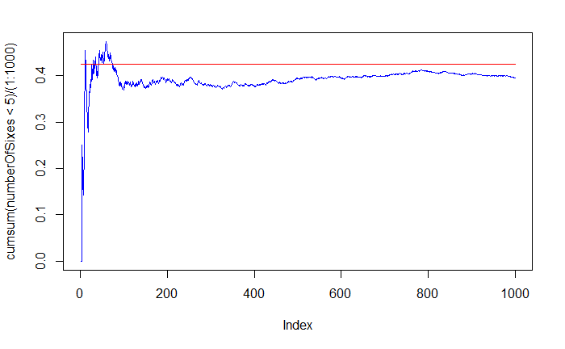

```r
lines(x0, col = "red")
```

```r
table(numberOfSixes)
```

```
numberOfSixes
  0   1   2   3   4   5   6   7   8   9  10  11  13  14
  3  29  76 138 149 186 156 132  80  31  13   5   1   1
```

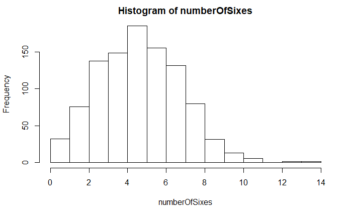

```r
hist(numberOfSixes)
```

```r
hist(numberOfSixes, probability = TRUE)
xvals = 0:30
points(xvals, dbinom(xvals, size = 30, prob = 1/6), type = "h", lwd = 3, col = "blue")
```

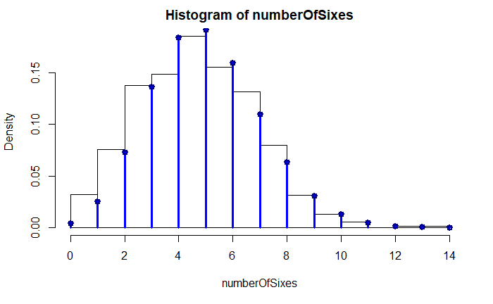

```r
points(xvals, dbinom(xvals, size = 30, prob = 1/6), type = "p", lwd = 3, col = "darkblue")
```

```r
# Можем да твърдим, че с вероятност 0.75 ще се паднат повече от колко шестици?
qbinom(0.75, size = 30, prob = 1/6, lower.tail = FALSE)
```

```
[1] 4
```

## Задача 2

Стрелец уцелва мишена с вероятност 0,2. За да спечели стрелецът трябва да направи три точни попадения. Каква е вероятноста за това да са му необходими:  
а) точно 8 изстрела;  
б) повече от 6 изстрела;  
в) между 5 и 8 изстрела, включително?

```r
# X ~ NBi(n = 3, p = 0.2)
# a) P(X = 8 - 3) = P(x = 5) = P(X <= 5) - P(X <= 4)
dnbinom(5, size = 3, prob = 0.2)
```

```
[1] 0.0551
```

```r
pnbinom(5, size = 3, prob = 0.2) - pnbinom(4, size = 3, prob = 0.2)
```

```
[1] 0.0551
```

```r
# б) P(X > 6 - 3) = P(X > 3)
pnbinom(3 , size = 3, prob = 0.2, lower.tail = FALSE)
```

```
[1] 0.901
```

```r
# в) P(5 - 3 <= X <= 8 - 3) = P(2 <= X <= 5) = P(X <= 5) - P(X <= 1)
pnbinom(5 , size = 3, prob = 0.2) - pnbinom(1 , size = 3, prob = 0.2)
```

```
[1] 0.176
```

## Задача 3

В урна има 7 бели и 6 черни топки. От урната последователно без връщане се теглят 8 топки. Нека X е броя на изтеглените бели. Направете 1000 симулации и по тях пресметнете границите, в който се намира X, EX и DX. Намерете теоретичните стойности за EX и DX. Представете графично емперичното и теоритичното разпределение на X(на една графика).

```r
# Без връщане => зависими опити
# X ~ HG(m = 7, n = 6, k = 8)
# m - брой бели топки в урната
# n - брой черни топки в урната
# k - броя на топките изтеглени от урната
# Направете 1000 симулации и по тях пресметнете границите, в който се намира X, EX и DX.
x = rhyper(1000, m = 7, n = 6, k = 8); head(x, 100)
```

```
  [1] 4 5 4 2 6 5 5 4 4 6 4 5 4 4 4 3 3 3 5 6 4 5 5 5 4 4 6 5 4 4 4 5 5 5 5 5 4 4 4 6 6 5 3 3 4 3 5 4 5 4 6 7 3
 [54] 5 4 4 6 5 3 5 5 3 4 3 4 4 4 3 4 5 5 5 3 4 4 3 4 5 4 2 4 5 4 4 5 4 5 3 6 5 5 4 3 6 4 5 4 4 4 4
```